# Lecture 28 – Data 100, Fall 2023

Data 100, Fall 2023

[Acknowledgments Page](https://ds100.org/fa23/acks/)

```python
from tensorflow.keras.layers import Input, Flatten, Dense, Dropout, Activation
from tensorflow.keras.models import Model, Sequential
from tensorflow.keras.optimizers.legacy import SGD
from tensorflow.keras.callbacks import Callback

from sklearn.datasets import make_circles
from sklearn.linear_model import LogisticRegression
from sklearn.model_selection import train_test_split

import numpy as np

import matplotlib.pyplot as plt

import io

from mlxtend.plotting import plot_decision_regions
```

```
2023-11-30 19:56:51.557177: I tensorflow/core/platform/cpu_feature_guard.cc:182] This TensorFlow binary is optimized to use available CPU instructions in performance-critical operations.
To enable the following instructions: SSE4.1 SSE4.2 AVX AVX2 FMA, in other operations, rebuild TensorFlow with the appropriate compiler flags.
```

First let's generate some data. We will be using SKLearn's make_circles to create a dataset that isn't linearly seperable.

```python
num_points = 300
x, y = make_circles(n_samples=num_points, random_state=144, shuffle=True, factor=0.7, noise=0.01)
y
```

```
array([0, 1, 1, 1, 0, 1, 1, 0, 1, 1, 1, 1, 1, 0, 1, 0, 0, 1, 0, 1, 1, 1,
       0, 1, 0, 0, 1, 0, 0, 0, 0, 0, 1, 0, 0, 1, 1, 1, 0, 0, 0, 0, 1, 1,
       0, 1, 0, 1, 0, 0, 1, 0, 1, 1, 1, 0, 0, 0, 0, 0, 0, 1, 1, 1, 0, 1,
       1, 1, 1, 1, 0, 1, 1, 0, 0, 0, 1, 1, 1, 1, 1, 1, 0, 1, 0, 1, 1, 0,
       0, 0, 0, 0, 1, 0, 1, 1, 1, 1, 0, 0, 1, 1, 1, 0, 1, 0, 0, 1, 0, 0,
       1, 1, 1, 0, 1, 0, 1, 1, 0, 0, 0, 1, 0, 0, 1, 0, 0, 0, 1, 0, 1, 1,
       0, 0, 0, 1, 0, 1, 0, 1, 1, 1, 1, 0, 0, 0, 0, 1, 1, 1, 0, 0, 0, 0,
       0, 1, 1, 1, 0, 0, 0, 0, 1, 1, 0, 1, 1, 1, 1, 0, 0, 0, 0, 1, 1, 0,
       1, 0, 1, 0, 1, 1, 0, 0, 0, 1, 1, 0, 0, 1, 1, 0, 1, 1, 0, 1, 0, 1,
       0, 1, 0, 0, 0, 1, 0, 0, 1, 0, 1, 0, 1, 0, 1, 1, 1, 0, 1, 0, 1, 0,
       1, 1, 0, 1, 0, 1, 1, 1, 0, 0, 1, 0, 1, 1, 0, 1, 1, 1, 1, 1, 1, 0,
       0, 0, 1, 0, 1, 0, 1, 1, 0, 0, 1, 0, 0, 0, 0, 0, 0, 0, 0, 0, 1, 1,
       1, 0, 1, 0, 1, 0, 0, 0, 0, 1, 0, 1, 1, 1, 1, 0, 0, 0, 1, 1, 1, 1,
       0, 1, 1, 0, 1, 0, 0, 0, 0, 0, 0, 1, 0, 1])
```

Let's visualize the data. As we can see, it consists of two concentric circles where the color of each point represents which class it belongs to.

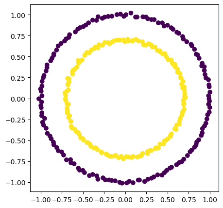

```python
plt.figure(figsize=(5,5))
plt.scatter(x[:, 0], x[:, 1], c=y)
plt.show()
```

To ensure we aren't overfitting during training, let's split our x and y data into training and testing sets.

To visualize why we want to use a neural network for this problem, let's try to use SKLearn's Logistic Regression to classify the points:

```
Training Score:  0.5083333333333333
Testing Score:  0.4666666666666667
```

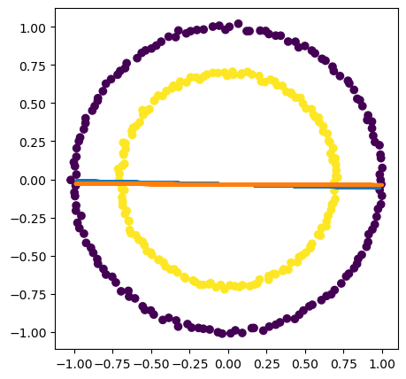

```python
def perform_logistic_regression(x, y):
    x_train, x_test, y_train, y_test = train_test_split(x, y, test_size=0.2, random_state=144)

    clf = LogisticRegression(random_state=144).fit(x_train, y_train)
    print('Training Score: ', clf.score(x_train, y_train))
    print('Testing Score: ', clf.score(x_test, y_test))

    plt.figure(figsize=(5,5))
    plt.scatter(x[:, 0], x[:, 1], c=y)

    plt.plot(x_test, clf.coef_ * x_test + clf.intercept_, linewidth=3)

    plt.show()

perform_logistic_regression(x, y)
```

It's apparent that our linear decision boundary won't cut it for this data. Let's try to build a simple neural network that can distinguish between these two classes:

```python
# tanh(x) = 2 * sigmoid(2x) - 1
def build_model1():
    input_layer = Input(shape=(2))
    x = Dense(8, activation='tanh')(input_layer)
    x = Dense(8, activation='tanh')(x)
    x = Dense(1, activation='sigmoid')(x)
    return Model(input_layer, x)
```

```python
def build_model2():
  model = Sequential()
  model.add(Dense(units = 8, input_dim=2, activation='tanh'))
  model.add(Dense(units = 8, activation='tanh'))
  model.add(Dense(units = 1, activation='sigmoid'))
  return model
```

```python
model = build_model1()
model.summary()
```

```
Model: "model"
_________________________________________________________________
 Layer (type)                Output Shape              Param #
=================================================================
 input_1 (InputLayer)        [(None, 2)]               0

 dense (Dense)               (None, 8)                 24

 dense_1 (Dense)             (None, 8)                 72

 dense_2 (Dense)             (None, 1)                 9

=================================================================
Total params: 105
Trainable params: 105
Non-trainable params: 0
_________________________________________________________________
```

Now we need to declare our optimizer and compile our model with our chosen loss, optimizer, and metrics.

```python
sgd = SGD(learning_rate=0.05, decay=1e-6, momentum=0.9)
model.compile(loss='binary_crossentropy',
              optimizer=sgd,
              metrics=['accuracy'])
```

Before we train our model, let's use mlxtend to visualize the decision boundary. We can see that it initially cannot distinguish between the two classes.

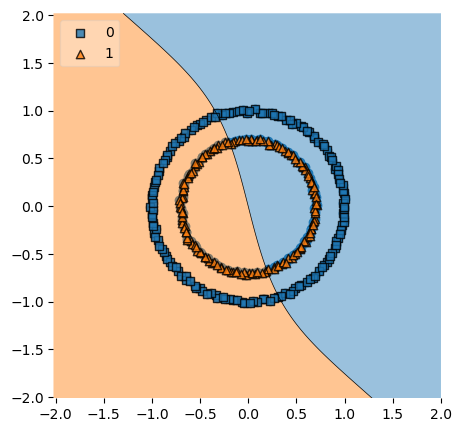

```python
plt.figure(figsize=(5,5))
plt.scatter(x[:, 0], x[:, 1])
plot_decision_regions(x, y, clf=model, legend=2)
plt.show()
```

For demonstration purposes, we create a callback to recreate the above plot every 10 epochs so we can visualize the progression of our decision boundary as we train our model.

```python
class ImgCallback(Callback):
    def on_epoch_begin(self, epoch, logs=None):
        if epoch % 10 == 0:
            fig = plt.figure(figsize=(5,5))
            plt.scatter(x[:, 0], x[:, 1])
            plot_decision_regions(x, y, clf=model, legend=2)
            plt.show()
            plt.close(fig)
```

Now let's train our model:

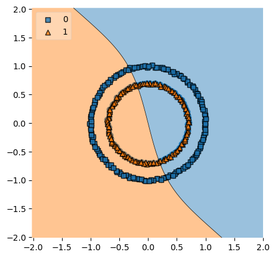

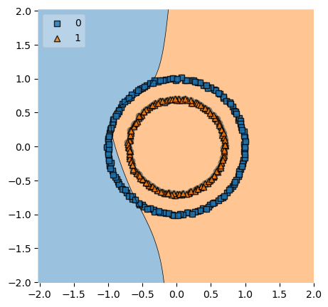

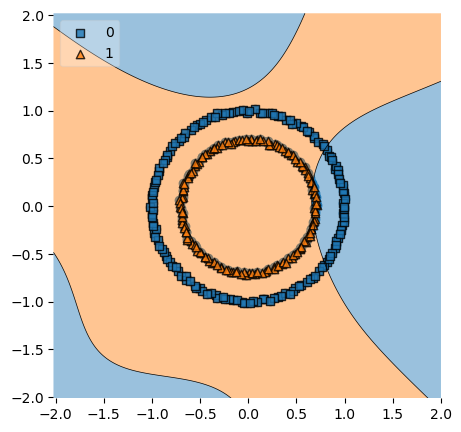

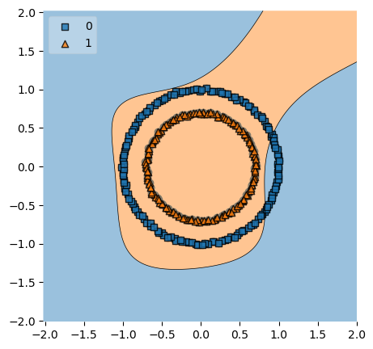

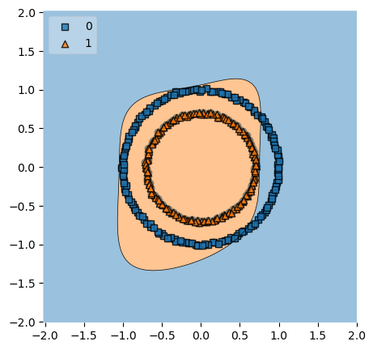

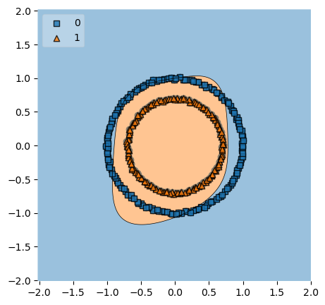

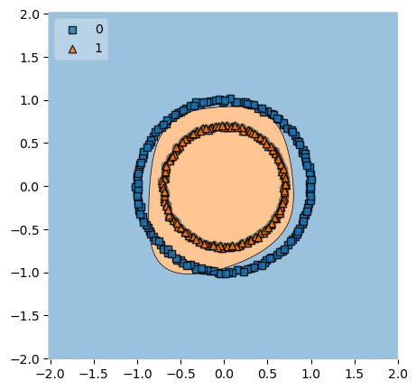

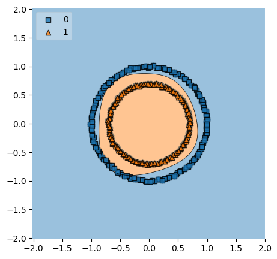

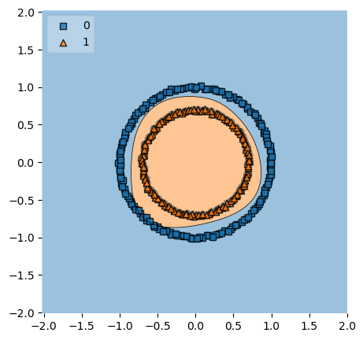

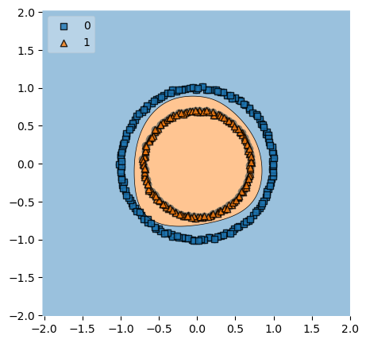

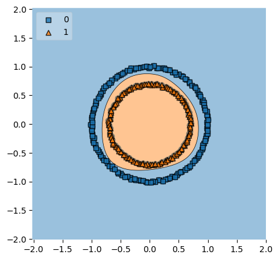

```python
# Create callback object
img_callback = ImgCallback()

# Perform model fitting
history = model.fit(x,
                    y,
                    epochs=100,
                    batch_size=128,
                    validation_split=0.2,
                    callbacks=[img_callback])

# Printing our last decision boundary plot
fig = plt.figure(figsize=(5,5))
plt.scatter(x[:, 0], x[:, 1])
plot_decision_regions(x, y, clf=model, legend=2)
plt.show()
plt.close(fig)
```

Here we define some functions to plot the history data that the fit() function returns:

```python
def plot_losses(hist):
    plt.plot(hist.history['loss'])
    plt.plot(hist.history['val_loss'])
    plt.title('Model Loss')
    plt.ylabel('Loss')
    plt.xlabel('Epoch')
    plt.legend(['Train', 'Val'])
    plt.show()

def plot_accuracies(hist):
    plt.plot(hist.history['accuracy'])
    plt.plot(hist.history['val_accuracy'])
    plt.title('Model Accuracy')
    plt.ylabel('Accuracy')
    plt.xlabel('Epoch')
    plt.legend(['Train', 'Val'])
    plt.show()
```

We can see that our train and test losses decrease with a similar trend and ending at a similar value. This is a good indication that we are not overfitting on our testing data.

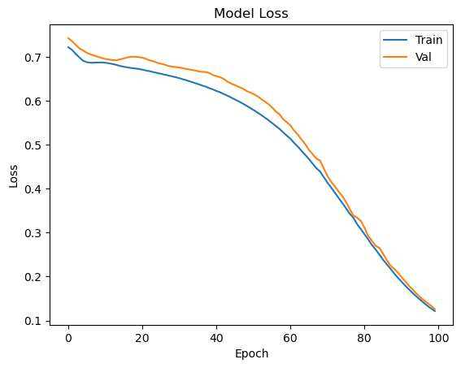

```python
plot_losses(history)
```

We can also observe model performance via accuracy. Accuracy is simply defined as the number of datapoints classified correctly over the total number of datapoints.

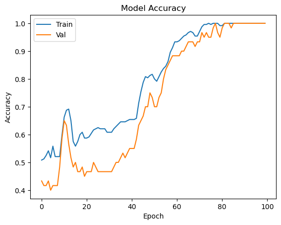

```python
plot_accuracies(history)
```